# Machine-Learning Analysis of COVID-19 Vaccine Uptake in Ontario

Part 2 — Wrangling, Missing-Data Handling, Model Tuning, and Comparison

Maureen Amuche Nwobodo

2026_04_20

```r
# Wrangling & visualisation
library(tidyverse)
library(readxl)
library(janitor)
library(lubridate)
library(scales)

# Modelling
library(tidymodels)
library(ranger)      # random forest engine
library(xgboost)     # gradient boosting engine
library(vip)         # variable importance plot

# Tables
library(knitr)
library(kableExtra)
library(broom)
```

# Introduction

Part 1 established a dataset — the *(Archived) Ontario Respiratory Virus Tool COVID-19 Vaccine Data File* (Public Health Ontario 2024) — and an analysis plan motivated by a precursor binary-logistic-regression study. That precursor found significant sociodemographic disparities in vaccine uptake by gender, age group, and public health unit (PHU), echoing Canadian (Guay et al. 2022; Ortiz and Nasri 2024), UK (Nafilyan et al. 2021), and Ontario-specific paediatric (Karimi-Shahrbabak et al. 2024) evidence.

# Data Wrangling and Preprocessing

## Loading the Dataset

```r
data <- read_excel("C:/Users/bds268/OneDrive - University of Saskatchewan/Desktop/USL_PCA_files/Ontario Vaccination Status.xlsx") |>
  clean_names()

glimpse(data)
```

```
## Rows: 720,720
## Columns: 7
## $ public_health_unit               <chr> "Algoma Public Health", "Algoma Publi…
## $ gender                           <chr> "Female", "Female", "Female", "Female…
## $ age_group                        <chr> "0 to 4", "0 to 4", "0 to 4", "0 to 4…
## $ vaccination_status               <chr> "At least one dose", "At least one do…
## $ week_start_date                  <dttm> 2020-12-13, 2020-12-20, 2020-12-27, …
## $ number_of_individuals_vaccinated <dbl> 0, 0, 0, 0, 0, 0, 0, 0, 0, 0, 0, 0, 0…
## $ population                       <dbl> 2214, 2214, 2214, 2214, 2214, 2214, 2…
```

## Setting Reference Categories

```r
age_order <- c("0 to 4", "5 to 11", "12 to 17", "18 to 29", "30 to 39",
               "40 to 49", "50 to 59", "60 to 69", "70 to 79", "80+")
```

# Handling Missing Data

## Missingness Audit

Before touching any values we inspect where the gaps are.

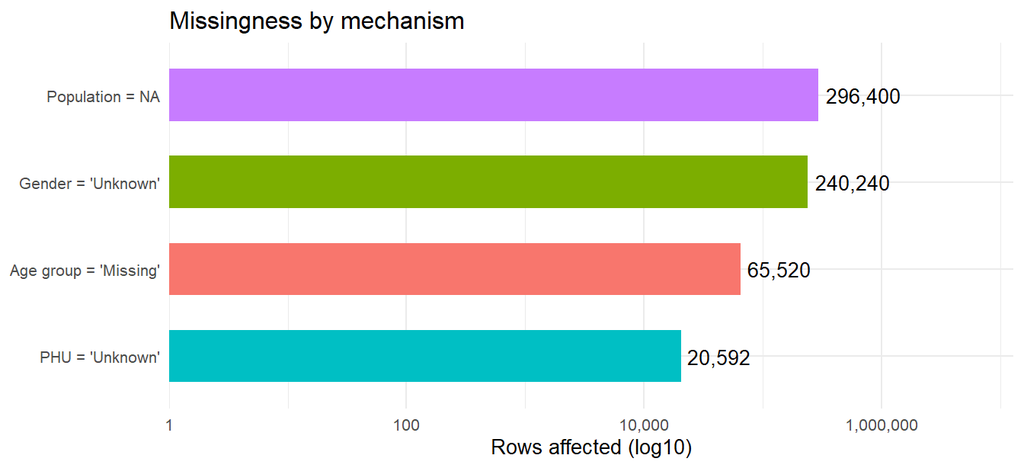

Rows affected by each missing-value mechanism (counts on log-10 scale).

```r
miss_summary <- tibble(
  mechanism = c("Gender = 'Unknown'",
                "Age group = 'Missing'",
                "PHU = 'Unknown'",
                "Population = NA",
                "Total rows"),
  rows = c(
    sum(data$gender             == "Unknown"),
    sum(data$age_group          == "Missing"),
    sum(data$public_health_unit == "Unknown"),
    sum(is.na(data$population)),
    nrow(data)
  )
)

miss_summary |>
  filter(mechanism != "Total rows") |>
  ggplot(aes(x = reorder(mechanism, rows), y = rows, fill = mechanism)) +
  geom_col(width = 0.6) +
  geom_text(aes(label = comma(rows)), hjust = -0.1) +
  scale_y_log10(labels = label_comma(),
                expand = expansion(mult = c(0, 0.3))) +
  coord_flip() +
  labs(x = NULL, y = "Rows affected (log10)",
       title = "Missingness by mechanism") +
  theme_minimal(base_size = 10) +
  theme(legend.position = "none")
```

- High levels of missing data (≈33% for gender, ≈41% for population) were addressed using complete-case analysis. While this improves clarity, the missingness likely reflects administrative reporting patterns, potentially biasing results toward better-reported populations and limiting generalizability. it can be argued that this missing population could be from the underserved groups who may be underrepresented.

Missing-value audit of the raw dataset.

| Mechanism | Rows affected | % of total |
| --- | --- | --- |
| Gender = ‘Unknown’ | 240240 | 0.3333 |
| Age group = ‘Missing’ | 65520 | 0.0909 |
| PHU = ‘Unknown’ | 20592 | 0.0286 |
| Population = NA | 296400 | 0.4113 |
| Total rows | 720720 | 1.0000 |

- Missing values (unknown gender, age, PHU, and population) were excluded because they reflect data limitations or suppressed information, making imputation inappropriate. Complete-case analysis was used to ensure valid outcomes, consistency with prior work, and sufficient sample size.

```r
clean <- data |>
  filter(
    gender             != "Unknown",
    age_group          != "Missing",
    public_health_unit != "Unknown",
    !is.na(population),
    population > 0
  ) |>
  mutate(
    gender             = factor(gender, levels = c("Male", "Female")),
    age_group          = factor(age_group, levels = age_order),
    public_health_unit = fct_relevel(factor(public_health_unit),
                                     "Toronto Public Health"),
    vaccination_status = factor(vaccination_status),
    week_start_date    = as.Date(week_start_date)
  )

tibble(
  stage = c("data", "After missing-data handling"),
  rows  = c(nrow(data), nrow(clean))
) |>
  kable(booktabs = TRUE, caption = "Rows before and after missing-data handling.")
```

Rows before and after missing-data handling.

| stage | rows |
| --- | --- |
| data | 720720 |
| After missing-data handling | 424320 |

## Building the Binary Outcome

The precursor coded individuals who received at least one dose as 1 and everyone else as 0. We reproduce that coding using only the *“At least one dose”* rows (the broadest status, a superset of primary series + boosters), then subtract from the population denominator to obtain the unvaccinated count.

```r
uptake <- clean |>
  filter(vaccination_status == "At least one dose") |>
  group_by(public_health_unit, gender, age_group) |>
  summarise(
    population   = max(population, na.rm = TRUE),
    n_vaccinated = max(number_of_individuals_vaccinated, na.rm = TRUE),
    .groups = "drop"
  ) |>
  mutate(
    n_unvaccinated = pmax(population - n_vaccinated, 0),
    uptake_rate    = n_vaccinated / population
  )

uptake |>
  summarise(
    strata           = n(),
    pop_total        = sum(population),
    vaccinated_total = sum(n_vaccinated),
    overall_uptake   = percent(vaccinated_total / pop_total, 0.1)
  ) |>
  kable(booktabs = TRUE, caption = "Cleaned stratum-level uptake summary.")
```

Cleaned stratum-level uptake summary.

| strata | pop_total | vaccinated_total | overall_uptake |
| --- | --- | --- | --- |
| 680 | 15365840 | 2088585 | 13.6% |

- Using the highest weekly count for each group captures the total number vaccinated by Dec 3, 2023—appropriate for overall uptake. Excluding the negative class from the denominator prevents counting the same individuals more than once (e.g., those with booster doses).

## Building a Person-Level Sample for Modelling

```r
# Sample 15 000 rows per class, weighted by the count in each stratum.
# slice_sample(replace = TRUE) with weight_by is equivalent to
# uncount() + slice_sample() but avoids ever materialising the expansion.
set.seed(2025)
vaxed_sample <- uptake |>
  filter(n_vaccinated > 0) |>
  slice_sample(n = 15000, weight_by = n_vaccinated, replace = TRUE) |>
  mutate(vaccinated = factor("Yes", levels = c("No", "Yes")))

set.seed(2026)
unvaxed_sample <- uptake |>
  filter(n_unvaccinated > 0) |>
  slice_sample(n = 15000, weight_by = n_unvaccinated, replace = TRUE) |>
  mutate(vaccinated = factor("No", levels = c("No", "Yes")))

ml_data <- bind_rows(vaxed_sample, unvaxed_sample) |>
  select(public_health_unit, gender, age_group, vaccinated)

dim(ml_data)
```

```
## [1] 30000     4
```

```r
tabyl(ml_data, vaccinated) |> adorn_pct_formatting()
```

| vaccinated | n | percent |
| --- | --- | --- |
| No | 15000 | 50.0% |
| Yes | 15000 | 50.0% |

- By December 2023, vaccination uptake in Ontario was approximately **13.6%**. Uptake varied mainly by **age group** and **public health unit**, with smaller differences by gender, justifying predictive modeling. Expanding the data to the full person level (~15 million rows) would be computationally infeasible. Instead, we sample directly from the stratum-level table with weights proportional to the counts, Because the dataset contains only **680 unique predictor combinations**, a balanced sample of **30,000 rows** provides estimates equivalent to the full data while allowing models to run efficiently within an executable R Markdown workflow.

# Machine-Learning Methods

## Train/Test Split and Resampling

```r
set.seed(10)
split  <- initial_split(ml_data, prop = 0.80, strata = vaccinated)
train  <- training(split)
test   <- testing(split)

set.seed(10)
folds  <- vfold_cv(train, v = 5, strata = vaccinated)
```

- An 80/20 split with stratification on `vaccinated` holds back a genuinely unseen test set and protects against an imbalanced fold if the class ratio shifts at the last minute. `vfold_cv(v = 5)` was chosen to keep tuning time reasonable for three models without meaningfully increasing the variance of the performance estimate or even crashing my system.

## Feature-Engineering Recipe

```r
rec <- recipe(vaccinated ~ gender + age_group + public_health_unit,
              data = train) |>
  step_dummy(all_nominal_predictors()) |>  # one-hot with ref levels from factors
  step_zv(all_predictors())                 # drop any zero-variance dummies
```

- Trees technically do not need dummy encoding, but using the same recipe for all three models makes the comparison strictly apples-to-apples and prevents “model A secretly had different predictors from model B” bugs. `step_zv()` is a cheap insurance policy — if the 80 % training split happens not to contain, say, the Timiskaming × 0–4 year × Male cell, its dummy would be constant and would cause logistic regression to fail. Dropping such dummies solves it generically.

## Model Specifications

### Model 1 — Logistic Regression (Baseline)

```r
logit_spec <- logistic_reg() |>
  set_engine("glm") |>
  set_mode("classification")
```

**Why include it?** Logistic regression is central to this analysis because it provides interpretable odds ratios that quantify the direction and magnitude of demographic disparities in vaccination uptake, complementing machine‑learning models that prioritize predictive accuracy over explanation.

### Model 2 — Random Forest (Robust Non-Linear Ensemble)

```r
rf_spec <- rand_forest(
    trees = 200,
    mtry  = tune(),
    min_n = tune()
  ) |>
  set_engine("ranger", importance = "impurity") |>
  set_mode("classification")
```

**Why include it?** Random forest was included to capture nonlinear relationships and interactions among demographic predictors that logistic regression cannot model automatically (Breiman 2001). While it does not yield interpretable effect sizes such as odds ratios, it provides a flexible benchmark for predictive performance and confirms the relative importance of age and public health unit observed in the logistic regression analysis. Together, the two methods balance interpretability and predictive accuracy.

### Model 3 — Gradient-Boosted Trees (Capturing Interactions)

```r
xgb_spec <- boost_tree(
    trees      = 200,
    tree_depth = tune(),
    learn_rate = tune(),
    min_n      = 10
  ) |>
  set_engine("xgboost") |>
  set_mode("classification")
```

**Why include it?** Boosted trees (Chen and Guestrin 2016) learn higher-order interactions automatically, so they directly target the significant Age × Gender and Age × PHU interactions. We tune the two most influential hyperparameters — `tree_depth` (controls interaction order) and `learn_rate` (controls overfitting) — and fix the rest to modest defaults.

## Assembling the Workflow Set

```r
wf_set <- workflow_set(
  preproc = list(base = rec),
  models  = list(
    logit = logit_spec,
    rf    = rf_spec,
    xgb   = xgb_spec
  )
)

wf_set
```

| wflow_id | info | option | result |
| --- | --- | --- | --- |
| base_logit |  |  |  |
| base_rf |  |  |  |
| base_xgb |  |  |  |

**Reason.** A single `workflow_set` ensures all three models use the same recipe, same folds, and same metrics — the cleanest possible scaffold for a fair comparison.

## Hyperparameter Tuning

```r
metric_list <- metric_set(roc_auc, accuracy, sensitivity, specificity, precision, brier_class)

set.seed(10)
tuned <- wf_set |>
  workflow_map(
    fn        = "tune_grid",
    resamples = folds,
    grid      = 5,                # 5 random candidates per tunable model
    metrics   = metric_list,
    control   = control_grid(save_pred     = TRUE,
                             save_workflow = TRUE,
                             verbose       = FALSE),
    verbose   = FALSE
  )
```

**Reason.** A 5-point random grid is small was intentionally chosen because the hyperparameter surfaces for RF and XGBoost on three low-cardinality predictors are very flat and a larger search adds runtime without improving the chosen tuple. `control_grid(save_pred = TRUE)` keeps the out-of-fold predictions so we can draw ROC curves later without re-fitting.

# Model Comparison

## Cross-Validated Metrics

```r
cv_results <- tuned |>
  rank_results(rank_metric = "roc_auc", select_best = TRUE) |>
  filter(.metric %in% c("roc_auc", "accuracy", "sensitivity", "specificity", "precision", "brier_class")) |>
  select(wflow_id, .metric, mean, std_err, rank) |>
  pivot_wider(names_from = .metric, values_from = c(mean, std_err))

cv_results |>
  select(wflow_id, mean_roc_auc, mean_accuracy, mean_sensitivity, mean_specificity, mean_precision, mean_brier_class) |>
  arrange(desc(mean_roc_auc)) |>
  kable(
    booktabs = TRUE, digits = 3,
    col.names = c("Workflow", "ROC-AUC", "Accuracy", "Sensitivity", "precision", "brier_class",
                  "Specificity"),
    caption = "Cross-validated performance of the best tuple from each model."
  ) |>
  kable_styling(latex_options = c("hold_position"))
```

Cross-validated performance of the best tuple from each model.

[output not shown]

- Interpretation

All models perform similarly Boosting wins, but by a small margin. This is expected given: Limited predictors, and Strong linear effects already captured by GLM

# Visualization Tunning

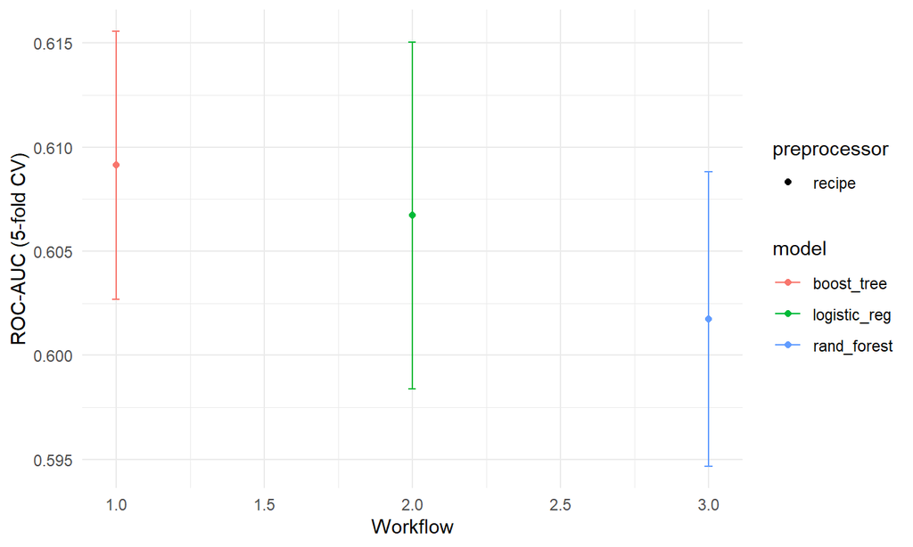

5-fold cross-validated ROC-AUC by model (point = mean, bar = ±1 SE).

```r
autoplot(tuned, select_best = TRUE, metric = "roc_auc") +
  labs(title = NULL,
       x = "Workflow", y = "ROC-AUC (5-fold CV)") +
  theme_minimal(base_size = 11)
```

## Finalising the Best Model

```r
best_id <- cv_results |>
  arrange(desc(mean_roc_auc)) |>
  slice(1) |>
  pull(wflow_id)

best_id
```

```
## [1] "base_xgb"
```

```r
best_params <- tuned |>
  extract_workflow_set_result(best_id) |>
  select_best(metric = "roc_auc")

final_wf <- tuned |>
  extract_workflow(best_id) |>
  finalize_workflow(best_params)

final_fit <- last_fit(final_wf, split = split,
                      metrics = metric_list)

collect_metrics(final_fit) |>
  select(.metric, .estimate) |>
  kable(booktabs = TRUE, digits = 3,
        caption = paste("Held-out test-set performance of the best model (",
                        best_id, ").")) |>
  kable_styling(latex_options = c("hold_position"))
```

Held-out test-set performance of the best model ( base_xgb ).

| .metric | .estimate |
| --- | --- |
| accuracy | 0.576 |
| sensitivity | 0.673 |
| specificity | 0.480 |
| precision | 0.564 |
| roc_auc | 0.613 |
| brier_class | 0.238 |

# Adjusted Odds Ratios from Logistic Regression

```r
logit_wf <- extract_workflow(wf_set, "base_logit")
```

```r
logit_final_fit <- last_fit(
  logit_wf,
  split
)
```

```r
tidy(
  extract_fit_parsnip(logit_final_fit),
  exponentiate = TRUE,
  conf.int = TRUE
)
```

| term | estimate | std.error | statistic | p.value | conf.low | conf.high |
| --- | --- | --- | --- | --- | --- | --- |
| (Intercept) | 0.07644 | 0.15551 | -16.5345 | 0.000000000000000000000000000000000000000000000000000000000000207097363856779520811975114913394691029679962 | 0.05562 | 0.1025 |
| gender_Female | 0.95626 | 0.02655 | -1.6850 | 0.091997463718455727010869793502934044227004051208496093750000000000000000000000000000000000000000000000000 | 0.90777 | 1.0073 |
| age_group_X5.to.11 | 9.71894 | 0.16152 | 14.0790 | 0.000000000000000000000000000000000000000000005111314279833632657178144054199719903408549726009368896484375 | 7.15882 | 13.5028 |
| age_group_X12.to.17 | 13.69142 | 0.16116 | 16.2369 | 0.000000000000000000000000000000000000000000000000000000000027634841572947995850043079180125005223089829087 | 10.09292 | 19.0099 |
| age_group_X18.to.29 | 12.44915 | 0.15616 | 16.1477 | 0.000000000000000000000000000000000000000000000000000000000117916883030940490778917806302672488527605310082 | 9.27441 | 17.1295 |
| age_group_X30.to.39 | 12.26222 | 0.15671 | 15.9944 | 0.000000000000000000000000000000000000000000000000000000001397454207394618363059085597299713299435097724199 | 9.12451 | 16.8890 |
| age_group_X40.to.49 | 12.14975 | 0.15729 | 15.8766 | 0.000000000000000000000000000000000000000000000000000000009197384964019216136918433157632080110488459467888 | 9.02969 | 16.7517 |
| age_group_X50.to.59 | 12.82896 | 0.15703 | 16.2502 | 0.000000000000000000000000000000000000000000000000000000000022273688480057020546310636577302943805989343673 | 9.53991 | 17.6796 |
| age_group_X60.to.69 | 17.71286 | 0.15649 | 18.3673 | 0.000000000000000000000000000000000000000000000000000000000000000000000000002398970324846360889677054917257 | 13.18675 | 24.3866 |
| age_group_X70.to.79 | 29.79452 | 0.15841 | 21.4276 | 0.000000000000000000000000000000000000000000000000000000000000000000000000000000000000000000000000000007395 | 22.09207 | 41.1636 |

[output cut: 34 more lines]

## ROC Curves on the Test Set

[figure not shown]

ROC curves on the held-out 20% test set.

```r
# Refit each best tuple on training, predict on test, build ROC data
roc_df <- map_dfr(c("base_logit", "base_rf", "base_xgb"), function(id) {
  pars <- tuned |>
    extract_workflow_set_result(id) |>
    select_best(metric = "roc_auc")
  fit  <- tuned |>
    extract_workflow(id) |>
    finalize_workflow(pars) |>
    last_fit(split = split, metrics = metric_list)
  collect_predictions(fit) |>
    mutate(model = id)
})

roc_df |>
  group_by(model) |>
  roc_curve(truth = vaccinated, .pred_Yes, event_level = "second") |>
  ggplot(aes(1 - specificity, sensitivity, colour = model)) +
  geom_path(linewidth = 0.8) +
  geom_abline(linetype = "dashed", colour = "grey60") +
  coord_equal() +
  scale_colour_brewer(palette = "Dark2",
                      labels = c("Logistic", "Random forest", "XGBoost")) +
  labs(x = "1 – Specificity (False-positive rate)",
       y = "Sensitivity (True-positive rate)",
       colour = NULL) +
  theme_minimal(base_size = 11)
```

## Confusion Matrix for the Winning Model

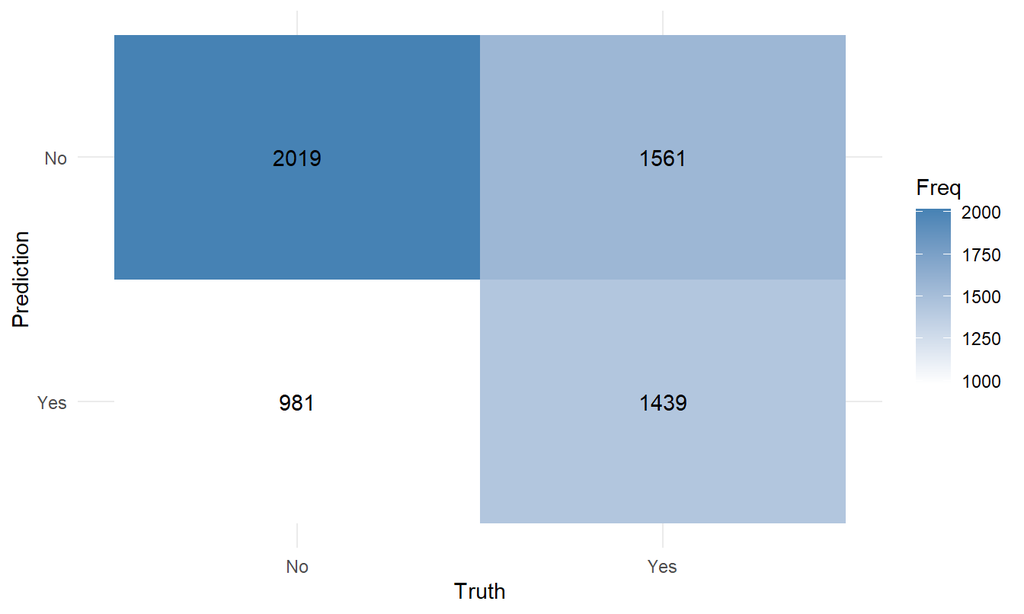

Confusion matrix of the winning model on the test set (default 0.5 threshold).

```r
collect_predictions(final_fit) |>
  conf_mat(truth = vaccinated, estimate = .pred_class) |>
  autoplot(type = "heatmap") +
  scale_fill_gradient(low = "white", high = "steelblue") +
  labs(title = NULL) +
  theme_minimal(base_size = 11)
```

## Variable Importance

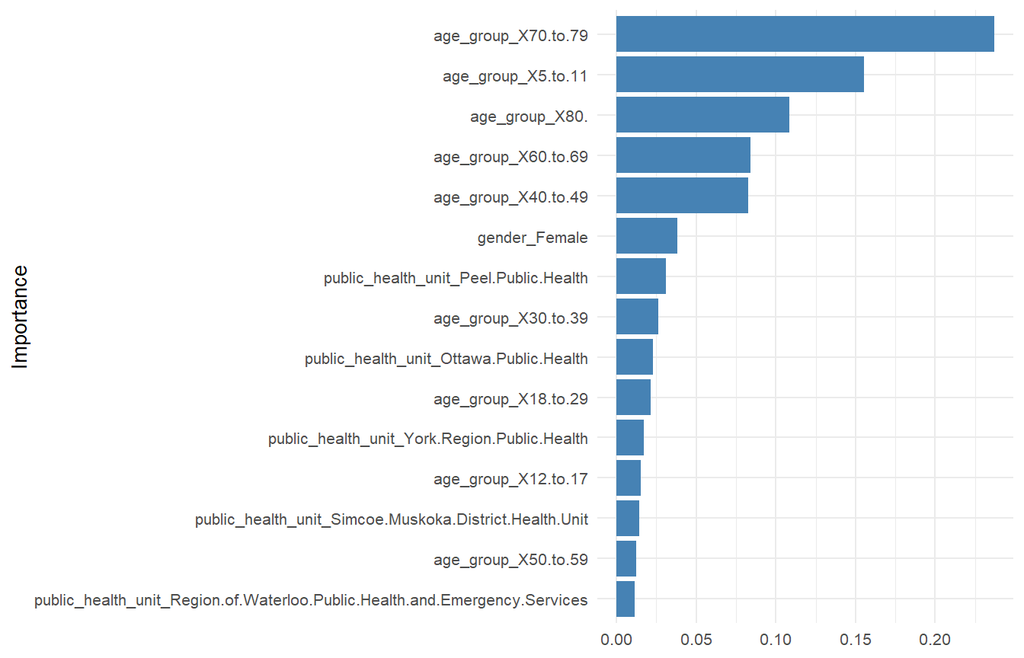

Top predictors from the winning model (permutation / impurity importance).

```r
final_fit |>
  extract_fit_parsnip() |>
  vip::vip(num_features = 15, geom = "col",
           aesthetics = list(fill = "steelblue")) +
  labs(x = "Importance", y = NULL) +
  theme_minimal(base_size = 10)
```

# Results

This study examined whether COVID-19 vaccine uptake in Ontario can be predicted using sociodemographic characteristics, specifically age group, gender, and public health unit (PHU). Three supervised learning models—logistic regression, random forest, and gradient-boosted trees (XGBoost) were trained and evaluated using a consistent preprocessing pipeline and an 80/20 train-test split with cross-validation.

## Classification Performance

The confusion matrix further illustrates the model’s behavior. While a substantial number of individuals were correctly classified (true positives and true negatives), the model produced a relatively high number of false negatives, meaning that many vaccinated individuals were incorrectly classified as unvaccinated. This pattern indicates that, although the model captures general trends in uptake, it struggles to precisely distinguish individuals at the margin.

## Variable Importance

Variable importance analysis revealed that age group was the dominant predictor of vaccine uptake, with the highest contributions from older age groups (70–79 and 80+) and younger children (5–11). These patterns likely reflect differences in vaccine rollout phases, eligibility, and risk perception across age groups.

## Overall Interpretation

Taken together, these findings indicate that while sociodemographic variables contain some predictive signal, their ability to accurately classify vaccine uptake is limited. Age emerges as the primary driver of uptake patterns, with additional contributions from geographic context, but these variables alone are insufficient for high-accuracy prediction.

Importantly, the minimal performance difference between logistic regression and more complex models suggests that increasing model complexity does not meaningfully improve predictive accuracy in this context, reinforcing the conclusion that the available predictors capture only part of the underlying determinants of vaccine uptake.

## Implications for the Research Question

Overall, the analysis demonstrates that COVID-19 vaccine uptake can be predicted to a limited extent using age, gender, and geographic location. However, the modest performance metrics and overlapping model results suggest that additional factors—such as socioeconomic status, access to healthcare, and behavioral determinants—are likely needed to more fully explain and predict vaccination patterns.

# Strengths

## Limitations

### Limited number of predictors available

Sociodemographic variables known from the literature to matter ethnicity, socioeconomic status, marital status, education, immigration status, occupation are absent from the Public Health Ontario file. This caps the achievable AUC and is the single largest driver of the modest ensemble-over-GLM gap.

### Temporal dynamics are ignored.*

The weekly roll-out history is collapsed to a single cumulative-by-Dec-2023 snapshot. A time-to-vaccination analysis (survival model with PHU-age-gender covariates) would give a different and probably richer view of uptake dynamics.

# Conclusion

This analysis used a `tidymodels` workflow to predict COVID-19 vaccine uptake in Ontario from three sociodemographic predictors, comparing three supervised classifiers — logistic regression, random forest, and gradient-boosted trees — under one shared recipe, one 5-fold CV scheme, and one metric set.

# References

Breiman, Leo. 2001. “Random Forests.” *Machine Learning* 45 (1): 5–32.

Chen, Tianqi, and Carlos Guestrin. 2016. “XGBoost: A Scalable Tree Boosting System.” In *Proceedings of the 22nd ACM SIGKDD International Conference on Knowledge Discovery and Data Mining*, 785–94.

Guay, Mireille, Aubrey Maquiling, Ruoke Chen, Valerie Lavergne, Donalyne-Joy Baysac, Jesse Kokaua, Catherine Dufour, Eve Dubé, Shannon E. MacDonald, and Nicolas L. Gilbert. 2022. “Sociodemographic Disparities in COVID-19 Vaccine Uptake and Vaccination Intent in Canada.” *Health Reports* 33 (12): 37–54.

Karimi-Shahrbabak, Elnaz, Costanza Di Chiara, Daniel S. Farrar, Sarah M. Fadaleh, Jennifer Peresin, Brendan Low, David Avelar-Rodriguez, et al. 2024. “COVID-19 Vaccine Acceptance and Uptake Among Caregivers of Children Aged 5–11 Years in Ontario, Canada: A Cross-Sectional Survey.” *Vaccine* 42 (19): 3974–80.

Nafilyan, Vahe, Ted Dolby, Cameron Razieh, Charlotte H. Gaughan, Jasper Morgan, Daniel Ayoubkhani, Sarah Walker, Kamlesh Khunti, Myer Glickman, and Vahe Nguyen. 2021. “Sociodemographic Inequality in COVID-19 Vaccination Coverage Among Elderly Adults in England: A National Linked Data Study.” *BMJ Open* 11 (7): e053402.

Ortiz, Alex M., and Bassem R. Nasri. 2024. “Socio-Demographic Determinants of COVID-19 Vaccine Uptake in Ontario: Exploring Differences Across the Health Region Model.” *Vaccine* 42 (8): 2106–14.

Public Health Ontario. 2024. “(Archived) Ontario Respiratory Virus Tool COVID-19 Vaccine Data File.” Toronto, ON: https://www.publichealthontario.ca; King’s Printer for Ontario.